# Tenth Week: Principal Component Analysis and Factor Analysis

PCA Stock, image, …

94101448

2018-05-19 10:16:39

> با استفاده از داده های OHLCV شرکت های تشکیل دهنده شاخص s&p500 و همچنین داده مربوط به شاخص های اقتصادی به سوالات زیر پاسخ دهید.

تاریخ شرکت های مختلف با هم فرق داشت با تقریب خوبی عمده ی شرکت ها ولی تاریخ یکسان دارند در برخی سوال ها مانند سوال ۵ که نیاز بود فقط این شرکت ها را در نظر گرفتیم

۱. چه شرکتی رکورددار کسب بیشترین سود در بازه یکساله، دو ساله و پنج ساله می باشد؟ این سوال را برای بخش های مختلف مورد مطالعه قرار دهید و رکورددار را معرفی کنید. (برای این کار به ستون sector داده constituents مراجعه کنید.) برای هر دو قسمت نمودار سود ده شرکت و یا بخش برتر را رسم نمایید.

نمودار شرکت دکورددار هر بخش و نمودار ۱۰ شرکت برتر هر بخش کشیده شده است

```r
myfiles=list()
proffile=list()


 tempname=str_split(temp,pattern = ".csv") %>% unlist() %>%
   as.data.frame(StringAsFactor=FALSE)


for (i in c(1:length(temp))) {
  data=read_csv(temp[i])
  myfiles[[i]]=data %>%
    mutate(Symbol=tempname$.[i*2-1],prof1year=data$Close[255]-data$Open[1],prof2year=data$Close[505]-data$Open[1],
           prof5year=data$Close[1261]-data$Open[1])

   dataprof=myfiles[[i]] %>% select(Symbol,prof1year,prof2year,prof5year)
   proffile[[i]]=dataprof[1,]

}
```

```r
companyprof=do.call("rbind",proffile)
companyprof=merge(companyprof,constituents)

top1year=companyprof %>% group_by(Sector) %>% mutate(rank=rank(-prof1year)) %>%
  arrange(Sector,rank) %>% filter(rank<11) %>% select(Symbol,prof1year,Sector,rank)

rank1year=companyprof %>% group_by(Sector) %>% mutate(rank=rank(-prof1year)) %>%
  arrange(Sector,rank) %>% filter(rank==1)%>% select(Symbol,Sector)

top2year=companyprof %>% group_by(Sector) %>% mutate(rank=rank(-prof2year)) %>%
  arrange(Sector,rank) %>% filter(rank<11) %>% select(Symbol,prof2year,Sector,rank)

rank2year=companyprof %>% group_by(Sector) %>% mutate(rank=rank(-prof1year)) %>%
  arrange(Sector,rank) %>% filter(rank==1)%>% select(Symbol,Sector)

top5year=companyprof %>% group_by(Sector) %>% mutate(rank=rank(-prof5year)) %>%
  arrange(Sector,rank) %>% filter(rank<11) %>% select(Symbol,prof5year,Sector,rank)

rank5year=companyprof %>% group_by(Sector) %>% mutate(rank=rank(-prof1year)) %>%
  arrange(Sector,rank) %>% filter(rank==1) %>% select(Symbol,Sector)

top1year %>% hchart("column",hcaes(x=Sector,y=prof1year,group=Symbol))
```

[interactive chart not shown]

```r
top2year %>% hchart("column",hcaes(x=Sector,y=prof2year,group=Symbol))
```

[interactive chart not shown]

```r
top5year %>% hchart("column",hcaes(x=Sector,y=prof5year,group=Symbol))
```

[interactive chart not shown]

```r
rank1year
```

```
## # A tibble: 11 x 2
## # Groups:   Sector [11]
##    Symbol Sector
##    <fct>  <chr>
##  1 KORS   Consumer Discretionary
##  2 KHC    Consumer Staples
##  3 EOG    Energy
##  4 ICE    Financials
##  5 LH     Health Care
##  6 LLL    Industrials
##  7 GOOG   Information Technology
##  8 LYB    Materials
##  9 ESS    Real Estate
## 10 T      Telecommunication Services
## 11 EXC    Utilities
```

```r
rank2year
```

```
## # A tibble: 11 x 2
## # Groups:   Sector [11]
##    Symbol Sector
##    <fct>  <chr>
##  1 KORS   Consumer Discretionary
##  2 KHC    Consumer Staples
##  3 EOG    Energy
##  4 ICE    Financials
##  5 LH     Health Care
##  6 LLL    Industrials
##  7 GOOG   Information Technology
##  8 LYB    Materials
##  9 ESS    Real Estate
## 10 T      Telecommunication Services
## 11 EXC    Utilities
```

```r
rank5year
```

```
## # A tibble: 11 x 2
## # Groups:   Sector [11]
##    Symbol Sector
##    <fct>  <chr>
##  1 KORS   Consumer Discretionary
##  2 KHC    Consumer Staples
##  3 EOG    Energy
##  4 ICE    Financials
##  5 LH     Health Care
##  6 LLL    Industrials
##  7 GOOG   Information Technology
##  8 LYB    Materials
##  9 ESS    Real Estate
## 10 T      Telecommunication Services
## 11 EXC    Utilities
```

۲. یک اعتقاد خرافی می گوید خرید سهام در روز سیزدهم ماه زیان آور است. این گزاره را مورد ارزیابی قرار دهید.

برای انجام این مقایسه میانگین اختلاف قیمت شروع و پایان بازار در روز ۱۳ ام و سایر روز های ماه را برای تمام شرکت ها با یک آزمون فرض بررسی میکنیم میبینیم که نمیتوانیم این ادعا که میانگین سود در روز ۱۳ ام با سایر روز ها متفاوت است را رد نتیجه بگیریم. در واقع آزمون فرض ما نتوانست یکسانی میانگین ها را رد کند

```r
meandate13=data.frame(prof=seq(0,0,length.out = length(temp)))
meannotdate13=data.frame(prof=seq(0,0,length.out = length(temp)))

for (i in c(1:length(temp))) {

  date13=myfiles[[i]] %>% mutate(date13=str_detect(Date,pattern = "-13"),dayprof=Close-Open) %>%
   filter(date13==TRUE) %>% select(dayprof)
  notdate13=myfiles[[i]] %>% mutate(date13=str_detect(Date,pattern = "-13"),dayprof=Close-Open) %>%
    filter(date13==FALSE) %>% select(dayprof)
  meandate13$prof[i]=mean(date13$dayprof,na.rm = TRUE)
  meannotdate13$prof[i]=mean(notdate13$dayprof,na.rm = TRUE)
}

t.test(meandate13,meannotdate13)
```

```
##
##  Welch Two Sample t-test
##
## data:  meandate13 and meannotdate13
## t = 0.081187, df = 544.75, p-value = 0.9353
## alternative hypothesis: true difference in means is not equal to 0
## 95 percent confidence interval:
##  -0.01400097  0.01520819
## sample estimates:
##  mean of x  mean of y
## 0.01238432 0.01178070
```

```r
# نمیتونیم بگوییم فرقی دارند
```

۳. رکورد بیشترین گردش مالی در تاریخ بورس برای چه روزی بوده است و چرا!!!

```r
#gardesh mali=sum(volume*(open-close))


cycle=do.call("rbind",myfiles)
cycledata=cycle %>% group_by(Date) %>%summarise(sum=sum(Volume*(Close-Open)))
cycledata$Date[which.max(cycledata$sum)]
```

```
## [1] "2008-10-10"
```

```r
max(cycledata$sum,na.rm = T)
```

```
## [1] 22371073691
```

برای توجیه اینکه چه شده میتوانیم به متن زیر نگاهی بیندازیم گویا در اکتبر ۲۰۰۸ وقایع زیادی در بازار بورس اتفاق افتاده و با سرچ در گوگل پست های زیادی در سایت های خبری با نام وقایع بازار بورس در اکتبر ۲۰۰۸ میبینیم

Global financial crisis in October 2008

On Thursday, October 9, the one-year anniversary of the Dow’s peak, the cost of short term credit rose while there were heavy losses in the United States stock market; the Dow dropped below 8600, reaching a five-year low. It was the first time since August 2003 that the Dow closed below 9000; losses were moderate in Europe.[52] The following day, Friday, October 10, there were large losses in Asian and European markets [53] Yamato Life filed for bankruptcy.

۴. شاخص AAPL که نماد شرکت اپل است را در نظر بگیرید. با استفاده از رگرسیون خطی یک پیش کننده قیمت شروع (open price) بر اساس k روز قبل بسازید. بهترین انتخاب برای k چه مقداری است؟ دقت پیش بینی شما چقدر است؟

```r
applereg=data.frame(open=seq(0,0,length.out = dim(apple)[1]-10),
                    day1=seq(0,0,length.out = dim(apple)[1]-10),
                    day2=seq(0,0,length.out = dim(apple)[1]-10),
                    day3=seq(0,0,length.out = dim(apple)[1]-10),
                    day4=seq(0,0,length.out = dim(apple)[1]-10),
                    day5=seq(0,0,length.out = dim(apple)[1]-10),
                    day6=seq(0,0,length.out = dim(apple)[1]-10),
                    day7=seq(0,0,length.out = dim(apple)[1]-10),
                    day8=seq(0,0,length.out = dim(apple)[1]-10),
                    day9=seq(0,0,length.out = dim(apple)[1]-10),
                    day10=seq(0,0,length.out = dim(apple)[1]-10))




for (i in c(11:dim(apple)[1])) {
  applereg$open[i-10]=apple$Open[i]

  applereg$day1[i-10]=apple$Open[i-1]
  applereg$day2[i-10]=apple$Open[i-2]
  applereg$day3[i-10]=apple$Open[i-3]
  applereg$day4[i-10]=apple$Open[i-4]
  applereg$day5[i-10]=apple$Open[i-5]
  applereg$day6[i-10]=apple$Open[i-6]
  applereg$day7[i-10]=apple$Open[i-7]
  applereg$day8[i-10]=apple$Open[i-8]
  applereg$day9[i-10]=apple$Open[i-9]
  applereg$day10[i-10]=apple$Open[i-10]


  }

index=sample(x=1:nrow(applereg),size=0.8*nrow(applereg),replace = F)
train=applereg[index,]
test=applereg[-index,]

#linear model
#k=1
fit = lm(open ~day1,data = train)
summary(fit)
```

```
##
## Call:
## lm(formula = open ~ day1, data = train)
##
## Residuals:
##     Min      1Q  Median      3Q     Max
## -556.64   -1.09   -0.07    1.28   53.48
##
## Coefficients:
##             Estimate Std. Error t value Pr(>|t|)
## (Intercept) 0.249365   0.257635   0.968    0.333
## day1        0.998749   0.001063 939.994   <2e-16 ***
## ---
## Signif. codes:  0 '***' 0.001 '**' 0.01 '*' 0.05 '.' 0.1 ' ' 1
##
## Residual standard error: 10.75 on 3411 degrees of freedom
## Multiple R-squared:  0.9962, Adjusted R-squared:  0.9962
## F-statistic: 8.836e+05 on 1 and 3411 DF,  p-value: < 2.2e-16
```

```r
predict=predict(fit,test)
error=abs(test$open-predict)/test$open#normalize
ERROR1=mean(error)
#k=2
fit = lm(open ~day1+day2,data = train)
summary(fit)
```

```
##
## Call:
## lm(formula = open ~ day1 + day2, data = train)
##
## Residuals:
##     Min      1Q  Median      3Q     Max
## -556.56   -1.08   -0.06    1.29   53.23
##
## Coefficients:
##             Estimate Std. Error t value Pr(>|t|)
## (Intercept)  0.23962    0.25763   0.930   0.3524
## day1         0.96992    0.01712  56.668   <2e-16 ***
## day2         0.02888    0.01712   1.687   0.0916 .
## ---
## Signif. codes:  0 '***' 0.001 '**' 0.01 '*' 0.05 '.' 0.1 ' ' 1
##
## Residual standard error: 10.74 on 3410 degrees of freedom
## Multiple R-squared:  0.9962, Adjusted R-squared:  0.9962
## F-statistic: 4.42e+05 on 2 and 3410 DF,  p-value: < 2.2e-16
```

```r
predict=predict(fit,test)
error=abs(test$open-predict)/test$open#normalize
ERROR2=mean(error)
#k=3
fit = lm(open ~day1+day2+day3,data = train)
summary(fit)
```

```
##
## Call:
## lm(formula = open ~ day1 + day2 + day3, data = train)
##
## Residuals:
##     Min      1Q  Median      3Q     Max
## -556.56   -1.08   -0.06    1.29   53.23
##
## Coefficients:
##              Estimate Std. Error t value Pr(>|t|)
## (Intercept) 0.2395551  0.2577272   0.929    0.353
## day1        0.9699166  0.0171251  56.637   <2e-16 ***
## day2        0.0286886  0.0239349   1.199    0.231
## day3        0.0002014  0.0172423   0.012    0.991
## ---
## Signif. codes:  0 '***' 0.001 '**' 0.01 '*' 0.05 '.' 0.1 ' ' 1
##
## Residual standard error: 10.75 on 3409 degrees of freedom
## Multiple R-squared:  0.9962, Adjusted R-squared:  0.9962
## F-statistic: 2.946e+05 on 3 and 3409 DF,  p-value: < 2.2e-16
```

```r
predict=predict(fit,test)
error=abs(test$open-predict)/test$open#normalize
ERROR3=mean(error)
#k=4
fit = lm(open ~day1+day2+day3+day4,data = train)
summary(fit)
```

```
##
## Call:
## lm(formula = open ~ day1 + day2 + day3 + day4, data = train)
##
## Residuals:
##     Min      1Q  Median      3Q     Max
## -556.36   -1.07   -0.06    1.28   53.00
##
## Coefficients:
##             Estimate Std. Error t value Pr(>|t|)
## (Intercept)  0.23194    0.25776   0.900    0.368
## day1         0.96992    0.01712  56.644   <2e-16 ***
## day2         0.02800    0.02394   1.170    0.242
## day3        -0.02218    0.02395  -0.926    0.354
## day4         0.02309    0.01715   1.346    0.178
## ---
## Signif. codes:  0 '***' 0.001 '**' 0.01 '*' 0.05 '.' 0.1 ' ' 1
##
## Residual standard error: 10.74 on 3408 degrees of freedom
## Multiple R-squared:  0.9962, Adjusted R-squared:  0.9962
## F-statistic: 2.21e+05 on 4 and 3408 DF,  p-value: < 2.2e-16
```

```r
predict=predict(fit,test)
error=abs(test$open-predict)/test$open#normalize
ERROR4=mean(error)
#k=5
fit = lm(open ~day1+day2+day3+day4+day5,data = train)
summary(fit)
```

```
##
## Call:
## lm(formula = open ~ day1 + day2 + day3 + day4 + day5, data = train)
##
## Residuals:
##     Min      1Q  Median      3Q     Max
## -555.67   -1.11   -0.07    1.30   54.68
##
## Coefficients:
##             Estimate Std. Error t value Pr(>|t|)
## (Intercept)  0.24049    0.25749   0.934  0.35037
## day1         0.97255    0.01713  56.784  < 2e-16 ***
## day2         0.02575    0.02392   1.076  0.28180
## day3        -0.01999    0.02393  -0.835  0.40361
## day4         0.13366    0.04134   3.233  0.00124 **
## day5        -0.11331    0.03856  -2.939  0.00332 **
## ---
## Signif. codes:  0 '***' 0.001 '**' 0.01 '*' 0.05 '.' 0.1 ' ' 1
##
## Residual standard error: 10.73 on 3407 degrees of freedom
## Multiple R-squared:  0.9962, Adjusted R-squared:  0.9962
## F-statistic: 1.772e+05 on 5 and 3407 DF,  p-value: < 2.2e-16
```

```r
predict=predict(fit,test)
error=abs(test$open-predict)/test$open#normalize
ERROR5=mean(error)
#k=6
fit = lm(open ~day1+day2+day3+day4+day5+day6,data = train)
summary(fit)
```

```
##
## Call:
## lm(formula = open ~ day1 + day2 + day3 + day4 + day5 + day6,
##     data = train)
##
## Residuals:
##     Min      1Q  Median      3Q     Max
## -555.59   -1.11   -0.07    1.29   54.18
##
## Coefficients:
##             Estimate Std. Error t value Pr(>|t|)
## (Intercept)  0.24510    0.25755   0.952  0.34132
## day1         0.97228    0.01713  56.757  < 2e-16 ***
## day2         0.02633    0.02393   1.100  0.27135
## day3        -0.02027    0.02394  -0.847  0.39706
## day4         0.13497    0.04137   3.263  0.00111 **
## day5        -0.09936    0.04162  -2.388  0.01701 *
## day6        -0.01530    0.01719  -0.890  0.37342
## ---
## Signif. codes:  0 '***' 0.001 '**' 0.01 '*' 0.05 '.' 0.1 ' ' 1
##
## Residual standard error: 10.73 on 3406 degrees of freedom
## Multiple R-squared:  0.9962, Adjusted R-squared:  0.9962
## F-statistic: 1.477e+05 on 6 and 3406 DF,  p-value: < 2.2e-16
```

```r
predict=predict(fit,test)
error=abs(test$open-predict)/test$open#normalize
ERROR6=mean(error)
#k=7
fit = lm(open ~day1+day2+day3+day4+day5+day6+day7,data = train)
summary(fit)
```

```
##
## Call:
## lm(formula = open ~ day1 + day2 + day3 + day4 + day5 + day6 +
##     day7, data = train)
##
## Residuals:
##     Min      1Q  Median      3Q     Max
## -555.47   -1.11   -0.07    1.29   53.78
##
## Coefficients:
##             Estimate Std. Error t value Pr(>|t|)
## (Intercept)  0.24018    0.25764   0.932  0.35128
## day1         0.97246    0.01713  56.759  < 2e-16 ***
## day2         0.02639    0.02393   1.103  0.27021
## day3        -0.02070    0.02395  -0.865  0.38727
## day4         0.13568    0.04138   3.279  0.00105 **
## day5        -0.10019    0.04163  -2.406  0.01616 *
## day6        -0.02805    0.02399  -1.169  0.24248
## day7         0.01308    0.01718   0.762  0.44639
## ---
## Signif. codes:  0 '***' 0.001 '**' 0.01 '*' 0.05 '.' 0.1 ' ' 1
##
## Residual standard error: 10.73 on 3405 degrees of freedom
## Multiple R-squared:  0.9962, Adjusted R-squared:  0.9962
## F-statistic: 1.266e+05 on 7 and 3405 DF,  p-value: < 2.2e-16
```

```r
predict=predict(fit,test)
error=abs(test$open-predict)/test$open#normalize
ERROR7=mean(error)
#k=8
fit = lm(open ~day1+day2+day3+day4+day5+day6+day7+day8,data = train)
summary(fit)
```

```
##
## Call:
## lm(formula = open ~ day1 + day2 + day3 + day4 + day5 + day6 +
##     day7 + day8, data = train)
##
## Residuals:
##     Min      1Q  Median      3Q     Max
## -555.45   -1.11   -0.06    1.31   53.52
##
## Coefficients:
##              Estimate Std. Error t value Pr(>|t|)
## (Intercept)  0.235293   0.257697   0.913  0.36128
## day1         0.972275   0.017135  56.744  < 2e-16 ***
## day2         0.026791   0.023938   1.119  0.26315
## day3        -0.020504   0.023946  -0.856  0.39192
## day4         0.134590   0.041398   3.251  0.00116 **
## day5        -0.099590   0.041639  -2.392  0.01682 *
## day6        -0.028380   0.023997  -1.183  0.23702
## day7        -0.002971   0.023989  -0.124  0.90146
## day8         0.016482   0.017199   0.958  0.33797
## ---
## Signif. codes:  0 '***' 0.001 '**' 0.01 '*' 0.05 '.' 0.1 ' ' 1
##
## Residual standard error: 10.73 on 3404 degrees of freedom
## Multiple R-squared:  0.9962, Adjusted R-squared:  0.9962
## F-statistic: 1.107e+05 on 8 and 3404 DF,  p-value: < 2.2e-16
```

```r
predict=predict(fit,test)
error=abs(test$open-predict)/test$open#normalize
ERROR8=mean(error)
#k=9
fit = lm(open ~day1+day2+day3+day4+day5+day6+day7+day8+day9,data = train)
summary(fit)
```

```
##
## Call:
## lm(formula = open ~ day1 + day2 + day3 + day4 + day5 + day6 +
##     day7 + day8 + day9, data = train)
##
## Residuals:
##     Min      1Q  Median      3Q     Max
## -555.28   -1.12   -0.06    1.31   53.51
##
## Coefficients:
##               Estimate Std. Error t value Pr(>|t|)
## (Intercept)  0.2301116  0.2577444   0.893  0.37203
## day1         0.9720313  0.0171360  56.724  < 2e-16 ***
## day2         0.0268431  0.0239378   1.121  0.26221
## day3        -0.0201820  0.0239482  -0.843  0.39943
## day4         0.1357401  0.0414123   3.278  0.00106 **
## day5        -0.1011789  0.0416676  -2.428  0.01522 *
## day6        -0.0280991  0.0239982  -1.171  0.24173
## day7        -0.0034572  0.0239939  -0.144  0.88544
## day8        -0.0005444  0.0238854  -0.023  0.98182
## day9         0.0175666  0.0170994   1.027  0.30434
## ---
## Signif. codes:  0 '***' 0.001 '**' 0.01 '*' 0.05 '.' 0.1 ' ' 1
##
## Residual standard error: 10.73 on 3403 degrees of freedom
## Multiple R-squared:  0.9962, Adjusted R-squared:  0.9962
## F-statistic: 9.843e+04 on 9 and 3403 DF,  p-value: < 2.2e-16
```

```r
predict=predict(fit,test)
error=abs(test$open-predict)/test$open#normalize
ERROR9=mean(error)
#k=10
fit = lm(open ~day1+day2+day3+day4+day5+day6+day7+day8+day9+day10,data = train)
summary(fit)
```

```
##
## Call:
## lm(formula = open ~ day1 + day2 + day3 + day4 + day5 + day6 +
##     day7 + day8 + day9 + day10, data = train)
##
## Residuals:
##     Min      1Q  Median      3Q     Max
## -555.15   -1.11   -0.06    1.32   53.30
##
## Coefficients:
##               Estimate Std. Error t value Pr(>|t|)
## (Intercept)  0.2246991  0.2578264   0.872  0.38354
## day1         0.9717533  0.0171395  56.697  < 2e-16 ***
## day2         0.0269299  0.0239388   1.125  0.26069
## day3        -0.0201422  0.0239490  -0.841  0.40038
## day4         0.1362545  0.0414178   3.290  0.00101 **
## day5        -0.1012355  0.0416691  -2.430  0.01517 *
## day6        -0.0287066  0.0240089  -1.196  0.23191
## day7        -0.0032930  0.0239954  -0.137  0.89085
## day8        -0.0007989  0.0238880  -0.033  0.97332
## day9         0.0028890  0.0238921   0.121  0.90376
## day10        0.0151008  0.0171673   0.880  0.37912
## ---
## Signif. codes:  0 '***' 0.001 '**' 0.01 '*' 0.05 '.' 0.1 ' ' 1
##
## Residual standard error: 10.73 on 3402 degrees of freedom
## Multiple R-squared:  0.9962, Adjusted R-squared:  0.9962
## F-statistic: 8.858e+04 on 10 and 3402 DF,  p-value: < 2.2e-16
```

```r
predict=predict(fit,test)
error=abs(test$open-predict)/test$open#normalize
ERROR10=mean(error)
```

۵. بر روی داده های قیمت شروع شرکت ها الگوریتم pca را اعمال کنید. نمودار تجمعی درصد واریانس بیان شده در مولفه ها را رسم کنید. سه مولفه اول چند درصد از واریانس را تبیین می کند؟

```r
library(qcc)
```

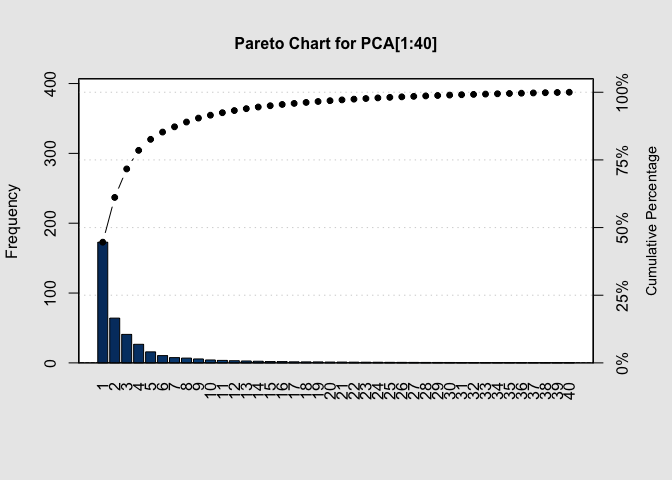

```
##
## Pareto chart analysis for PCA[1:40]
##         Frequency    Cum.Freq.   Percentage Cum.Percent.
##   1  172.82252361 172.82252361  44.59578458  44.59578458
##   2   64.10154094 236.92406455  16.54100664  61.13679122
##   3   40.79994100 277.72400555  10.52817273  71.66496395
##   4   26.60280467 304.32681023   6.86468940  78.52965335
##   5   15.77386911 320.10067934   4.07034948  82.60000283
##   6   10.41418146 330.51486080   2.68731519  85.28731802
##   7    7.52834665 338.04320745   1.94264335  87.22996137
##   8    6.84825168 344.89145913   1.76714904  88.99711041
##   9    5.62990932 350.52136844   1.45276332  90.44987372
##   10   4.15836620 354.67973464   1.07304071  91.52291443
##   11   3.56151615 358.24125079   0.91902724  92.44194167
##   12   3.07408277 361.31533356   0.79324807  93.23518974
```

[output cut: 28 more lines]

```r
data_5=myfiles[[1]] %>% select(Date,Open)
for (i in c(2:length(temp))) {
  if(dim(myfiles[[i]])[1]==4277){
    data_5=cbind(data_5,myfiles[[i]] %>% select(Open))
  }}
colnames(data_5)=c(1:398)
pca=prcomp(data_5 %>% select(-`1`),center = TRUE,scale. = TRUE)

PCA = pca$sdev^2
names(PCA)=c(1:397)
# for visibility
pareto.chart(PCA[1:40])
```

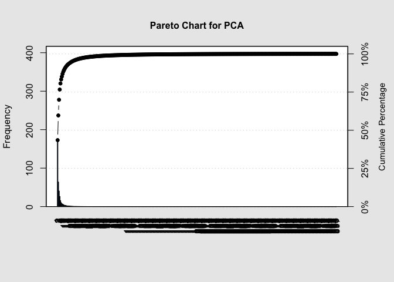

```
##
## Pareto chart analysis for PCA
##          Frequency    Cum.Freq.   Percentage Cum.Percent.
##   1   1.728225e+02 1.728225e+02 4.353212e+01 4.353212e+01
##   2   6.410154e+01 2.369241e+02 1.614648e+01 5.967861e+01
##   3   4.079994e+01 2.777240e+02 1.027706e+01 6.995567e+01
##   4   2.660280e+01 3.043268e+02 6.700958e+00 7.665663e+01
##   5   1.577387e+01 3.201007e+02 3.973267e+00 8.062989e+01
##   6   1.041418e+01 3.305149e+02 2.623220e+00 8.325311e+01
##   7   7.528347e+00 3.380432e+02 1.896309e+00 8.514942e+01
##   8   6.848252e+00 3.448915e+02 1.725000e+00 8.687442e+01
##   9   5.629909e+00 3.505214e+02 1.418113e+00 8.829254e+01
##   10  4.158366e+00 3.546797e+02 1.047447e+00 8.933998e+01
##   11  3.561516e+00 3.582413e+02 8.971073e-01 9.023709e+01
##   12  3.074083e+00 3.613153e+02 7.743282e-01 9.101142e+01
```

[output cut: 385 more lines]

```r
pareto.chart(PCA)
```

۶. برای هر نماد اطلاعات بخش مربوطه را از داده constituents استخراج نمایید. برای هر بخش میانگین روزانه قیمت شروع شرکت های آن را محاسبه کنید. سپس با استفاده از میانگین به دست آمده داده ایی با چند ستون که هر ستون یک بخش و هر سطر یک روز هست بسازید. داده مربوط را با داده شاخص های اقتصادی ادغام کنید. بر روی این داده pca بزنید و نمودار biplot آن را تفسیر کنید.

نموداری است که هم مشاهدات هم متغیر ها را روی یک نمودار نشان میدهد نقاط و بردار های نمودار تفسیر میشوند تفسیر نقاط:نقاط کنار هم به معنای نقاطی است که اسکور شبیه به هم دارند یعنی قیمت شروع شبیه ای دارند

تفسیر بردار ها: طول بردار متناسب با آر دو ی متغیر فیت شده و متغیر اصلی است بردار ذر جهتی است که بیشترین آر دو با پی سی به وجود میاید

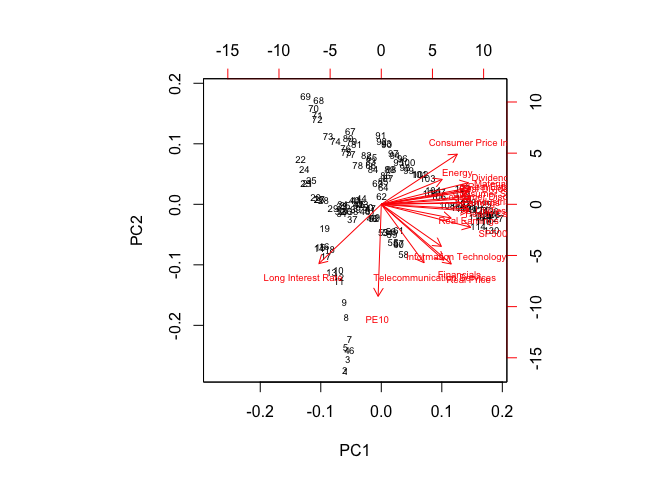

```r
library(tidyr)

myfiles_selected=list()
count=1;
for (i in c(1:length(temp))) {
  if(dim(myfiles[[i]])[1]==4277){
     myfiles_selected[[count]]=myfiles[[i]] %>% select(Date,Open,Symbol)
     myfiles_selected[[count]]=merge(myfiles_selected[[count]],constituents)
     count=count+1;
  }}
sectoropen=do.call("rbind",myfiles_selected)
sectoropen=sectoropen %>% group_by(Sector,Date) %>%summarise(mean=mean(Open))

spreaddata=sectoropen %>% spread(Sector,mean)
indexdata=merge(spreaddata,indexes)

pca=prcomp(indexdata %>% select(-Date),center = TRUE,scale. = TRUE)
biplot(pca,cex=0.6)
```

۷. روی همه اطلاعات (OHLCV) سهام اپل الگوریتم PCA را اعمال کنید. سپس از مولفه اول برای پیش بینی قیمت شروع سهام در روز آینده استفاده کنید. به سوالات سوال ۴ پاسخ دهید. آیا استفاده از مولفه اول نتیجه بهتری نسبت به داده open price برای پیش بینی قیمت دارد؟